# no-show-appointment-analysis-project

### Contents Table

Introduction

Making a Copy of The Dataset

Data Wrangling

Data Cleaning

- 1. Renaming Columns
- 2. Dropping Columns
- 3. Normalizing the scheduled_date so as to extract the years, months and date for further analysis
- 4. Normalizing the appointment date so as to extract the years, months and date for further analysis
- 5. Normalizing the appointment date so as to extract the actual month value
- 6.Categorizing the dataset into different age ranges
- 7. Removing the outliers in agecolumn
- 8. Removing the outliers in handicap column

Exporting the Cleaned Data to a New csv

Data Exploratory Analysis

Conclusions

Limitations

References

# Introduction

This dataset collects information from over 100k medical appointments in Brazil. The aim of analysing this dataset is to draw to out different insights, inferences and also focused on the several factors that determine whether or not patients show up for their appointment.

From the dataset given, I will be looking at answering the following questions:

- Question 1. How frequently do patients show up for their appointments during the week?
- Question 2. How does the neighborhood affect the rate at which people show up for their appointments?
- Question 3. Does SMS reminders influence how patients respond to their appointments?
- Question 4. Are the handicapped patients able to meet or miss their appointments?
- Question 5. How do hypertension, diabetes, and alcoholism affect the ability of patients to show up or not for their appointments?
- Question 6. What is the percentage of scholarship recipients? Does this affect whether they show up for their appointment or not?
- Question 7. Does age group have any impact on a patient's appointment availability?
- Question 8. Is there any relationship between hypertension and age among the patients?
- Question 9. Is there any relationship between alcoholism and age among the patients?
- Question 10. Is there any relationship between diabetes and age among the patients?
- Question 11. Are patients given scholarship based on gender?
- Question 12. What is the monthly analysis of show-up and no-show appointments?

```python
#import pandas
import pandas as pd
## load noshowappointments-kagglev2-may-2016 csv
df = pd.read_csv('./noshowappointments-kagglev2-may-2016.csv',sep=',')
#view all datasets
df.head()
```

|  | PatientId | AppointmentID | Gender | ScheduledDay | AppointmentDay | Age | Neighbourhood | Scholarship | Hipertension | Diabetes | Alcoholism | Handcap | SMS_received | No-show |
| --- | --- | --- | --- | --- | --- | --- | --- | --- | --- | --- | --- | --- | --- | --- |
| 0 | 2.987250e+13 | 5642903 | F | 2016-04-29T18:38:08Z | 2016-04-29T00:00:00Z | 62 | JARDIM DA PENHA | 0 | 1 | 0 | 0 | 0 | 0 | No |
| 1 | 5.589978e+14 | 5642503 | M | 2016-04-29T16:08:27Z | 2016-04-29T00:00:00Z | 56 | JARDIM DA PENHA | 0 | 0 | 0 | 0 | 0 | 0 | No |
| 2 | 4.262962e+12 | 5642549 | F | 2016-04-29T16:19:04Z | 2016-04-29T00:00:00Z | 62 | MATA DA PRAIA | 0 | 0 | 0 | 0 | 0 | 0 | No |
| 3 | 8.679512e+11 | 5642828 | F | 2016-04-29T17:29:31Z | 2016-04-29T00:00:00Z | 8 | PONTAL DE CAMBURI | 0 | 0 | 0 | 0 | 0 | 0 | No |
| 4 | 8.841186e+12 | 5642494 | F | 2016-04-29T16:07:23Z | 2016-04-29T00:00:00Z | 56 | JARDIM DA PENHA | 0 | 1 | 1 | 0 | 0 | 0 | No |

## Making a Copy of The Dataset

**I would be working with this copy through out the project while the original dataframe would be for referencing when needed** .

```python
#making a copy of my dataset
df2 = df.copy()
df2.head()
```

|  | PatientId | AppointmentID | Gender | ScheduledDay | AppointmentDay | Age | Neighbourhood | Scholarship | Hipertension | Diabetes | Alcoholism | Handcap | SMS_received | No-show |
| --- | --- | --- | --- | --- | --- | --- | --- | --- | --- | --- | --- | --- | --- | --- |
| 0 | 2.987250e+13 | 5642903 | F | 2016-04-29T18:38:08Z | 2016-04-29T00:00:00Z | 62 | JARDIM DA PENHA | 0 | 1 | 0 | 0 | 0 | 0 | No |
| 1 | 5.589978e+14 | 5642503 | M | 2016-04-29T16:08:27Z | 2016-04-29T00:00:00Z | 56 | JARDIM DA PENHA | 0 | 0 | 0 | 0 | 0 | 0 | No |
| 2 | 4.262962e+12 | 5642549 | F | 2016-04-29T16:19:04Z | 2016-04-29T00:00:00Z | 62 | MATA DA PRAIA | 0 | 0 | 0 | 0 | 0 | 0 | No |
| 3 | 8.679512e+11 | 5642828 | F | 2016-04-29T17:29:31Z | 2016-04-29T00:00:00Z | 8 | PONTAL DE CAMBURI | 0 | 0 | 0 | 0 | 0 | 0 | No |
| 4 | 8.841186e+12 | 5642494 | F | 2016-04-29T16:07:23Z | 2016-04-29T00:00:00Z | 56 | JARDIM DA PENHA | 0 | 1 | 1 | 0 | 0 | 0 | No |

# Data Wrangling

**Exploring the dataset, the next few cells gives insight on the `general information` of the dataset**

```python
#below are the details of the dataset
df2.info()
```

```
<class 'pandas.core.frame.DataFrame'>
RangeIndex: 110527 entries, 0 to 110526
Data columns (total 14 columns):
 #   Column          Non-Null Count   Dtype
---  ------          --------------   -----
 0   PatientId       110527 non-null  float64
 1   AppointmentID   110527 non-null  int64
 2   Gender          110527 non-null  object
 3   ScheduledDay    110527 non-null  object
 4   AppointmentDay  110527 non-null  object
 5   Age             110527 non-null  int64
 6   Neighbourhood   110527 non-null  object
 7   Scholarship     110527 non-null  int64
 8   Hipertension    110527 non-null  int64
 9   Diabetes        110527 non-null  int64
 10  Alcoholism      110527 non-null  int64
 11  Handcap         110527 non-null  int64
 12  SMS_received    110527 non-null  int64
 13  No-show         110527 non-null  object
dtypes: float64(1), int64(8), object(5)
memory usage: 11.8+ MB
```

```python
#the shape of the dataset
df2.shape
```

```
(110527, 14)
```

```python
#to ensure and confirming no null values in the data
df.isnull().sum()
```

```
PatientId         0
AppointmentID     0
Gender            0
ScheduledDay      0
AppointmentDay    0
Age               0
Neighbourhood     0
Scholarship       0
Hipertension      0
Diabetes          0
Alcoholism        0
Handcap           0
SMS_received      0
No-show           0
dtype: int64
```

```python
#the full description of the datasset
df2.describe()
```

|  | PatientId | AppointmentID | Age | Scholarship | Hipertension | Diabetes | Alcoholism | Handcap | SMS_received |
| --- | --- | --- | --- | --- | --- | --- | --- | --- | --- |
| count | 1.105270e+05 | 1.105270e+05 | 110527.000000 | 110527.000000 | 110527.000000 | 110527.000000 | 110527.000000 | 110527.000000 | 110527.000000 |
| mean | 1.474963e+14 | 5.675305e+06 | 37.088874 | 0.098266 | 0.197246 | 0.071865 | 0.030400 | 0.022248 | 0.321026 |
| std | 2.560949e+14 | 7.129575e+04 | 23.110205 | 0.297675 | 0.397921 | 0.258265 | 0.171686 | 0.161543 | 0.466873 |
| min | 3.921784e+04 | 5.030230e+06 | -1.000000 | 0.000000 | 0.000000 | 0.000000 | 0.000000 | 0.000000 | 0.000000 |
| 25% | 4.172614e+12 | 5.640286e+06 | 18.000000 | 0.000000 | 0.000000 | 0.000000 | 0.000000 | 0.000000 | 0.000000 |
| 50% | 3.173184e+13 | 5.680573e+06 | 37.000000 | 0.000000 | 0.000000 | 0.000000 | 0.000000 | 0.000000 | 0.000000 |
| 75% | 9.439172e+13 | 5.725524e+06 | 55.000000 | 0.000000 | 0.000000 | 0.000000 | 0.000000 | 0.000000 | 1.000000 |
| max | 9.999816e+14 | 5.790484e+06 | 115.000000 | 1.000000 | 1.000000 | 1.000000 | 1.000000 | 4.000000 | 1.000000 |

```python
#finding out the the types of data in each column
df2.dtypes
```

```
PatientId         float64
AppointmentID       int64
Gender             object
ScheduledDay       object
AppointmentDay     object
Age                 int64
Neighbourhood      object
Scholarship         int64
Hipertension        int64
Diabetes            int64
Alcoholism          int64
Handcap             int64
SMS_received        int64
No-show            object
dtype: object
```

```python
#counts of dupilicated values in each columns
df2.duplicated().value_counts()
```

```
False    110527
dtype: int64
```

**The above analysis confirms the data has no `null`, `duplicated` and `missing values`.**

## Data Cleaning

In data cleaning, there are basic things to consider before proceeding with the analysis of the data. This is to remove any inconsistencies, irregularities and to ensure that your data is of high relevance, high intergity and also for validity. There are several data cleaning processes that would be adopted through out this dataset

1. Renaming:Some columns headers in this dataset are misspelt with each other, this would be looked into properly and corrected as necessary, this would give clarity and also makes it easier to understand the use case of each columns as these column holds the properties of the data
2. Drop Columns: Some columns in this dataset would be dropped due to their irrelevancy towards further analysis. These include `patient_id` and`appointment_id`.
3. Converting our datetimes in the dataset into python datetimes: This is to enable us do further analysis relating to a particular period within the data set.
4. Categorizing the dataset: Specific columns like age group were categorised using bin into different buckets. This would enable us perform specific analysis based on age range.
5. Remove Outliers: There are certain outliers in some of the columns, such as in `age` and `handicap` columns. In this dataset, they are problematic and affect the result of our analysis.

#### 1. Renaming Columns

```python
#renaming the dataset columns for accuracy
df2.rename(columns = {'PatientId':'patient_id','AppointmentID':'appointment_id','ScheduledDay':'scheduled_date','Gender':'gender','AppointmentDay':'appointment_date', 'Age':'age', 'Neighbourhood':'neighbourhood','Scholarship':'scholarship',
                      'Hipertension':'hypertension', 'Diabetes':'diabetes','Alcoholism':'alcoholism','Handcap':'handicap','SMS_received':'sms_received','No-show':'no_show'}, inplace = True)
df2.head(5)
```

|  | patient_id | appointment_id | gender | scheduled_date | appointment_date | age | neighbourhood | scholarship | hypertension | diabetes | alcoholism | handicap | sms_received | no_show |
| --- | --- | --- | --- | --- | --- | --- | --- | --- | --- | --- | --- | --- | --- | --- |
| 0 | 2.987250e+13 | 5642903 | F | 2016-04-29T18:38:08Z | 2016-04-29T00:00:00Z | 62 | JARDIM DA PENHA | 0 | 1 | 0 | 0 | 0 | 0 | No |
| 1 | 5.589978e+14 | 5642503 | M | 2016-04-29T16:08:27Z | 2016-04-29T00:00:00Z | 56 | JARDIM DA PENHA | 0 | 0 | 0 | 0 | 0 | 0 | No |
| 2 | 4.262962e+12 | 5642549 | F | 2016-04-29T16:19:04Z | 2016-04-29T00:00:00Z | 62 | MATA DA PRAIA | 0 | 0 | 0 | 0 | 0 | 0 | No |
| 3 | 8.679512e+11 | 5642828 | F | 2016-04-29T17:29:31Z | 2016-04-29T00:00:00Z | 8 | PONTAL DE CAMBURI | 0 | 0 | 0 | 0 | 0 | 0 | No |
| 4 | 8.841186e+12 | 5642494 | F | 2016-04-29T16:07:23Z | 2016-04-29T00:00:00Z | 56 | JARDIM DA PENHA | 0 | 1 | 1 | 0 | 0 | 0 | No |

#### 2. Dropping Columns

```python
df2.drop(['patient_id', 'appointment_id'], axis=1, inplace=True, errors='ignore')
```

#### 3. Normalizing the scheduled_date so as to extract the years, months and date for further analysis

```python
#extraction analysis on scheduled_date
df2['new_scheduled_date'] = pd.to_datetime(df2.scheduled_date).dt.strftime('%Y-%m-%d')
df2['scheduled_month'] = pd.to_datetime(df2.scheduled_date).dt.month
df2['scheduled_year'] = pd.to_datetime(df2.scheduled_date).dt.year
df2['scheduled_day'] = pd.to_datetime(df2.scheduled_date).dt.day
df2.head()
```

|  | gender | scheduled_date | appointment_date | age | neighbourhood | scholarship | hypertension | diabetes | alcoholism | handicap | sms_received | no_show | new_scheduled_date | scheduled_month | scheduled_year | scheduled_day |
| --- | --- | --- | --- | --- | --- | --- | --- | --- | --- | --- | --- | --- | --- | --- | --- | --- |
| 0 | F | 2016-04-29T18:38:08Z | 2016-04-29T00:00:00Z | 62 | JARDIM DA PENHA | 0 | 1 | 0 | 0 | 0 | 0 | No | 2016-04-29 | 4 | 2016 | 29 |
| 1 | M | 2016-04-29T16:08:27Z | 2016-04-29T00:00:00Z | 56 | JARDIM DA PENHA | 0 | 0 | 0 | 0 | 0 | 0 | No | 2016-04-29 | 4 | 2016 | 29 |
| 2 | F | 2016-04-29T16:19:04Z | 2016-04-29T00:00:00Z | 62 | MATA DA PRAIA | 0 | 0 | 0 | 0 | 0 | 0 | No | 2016-04-29 | 4 | 2016 | 29 |
| 3 | F | 2016-04-29T17:29:31Z | 2016-04-29T00:00:00Z | 8 | PONTAL DE CAMBURI | 0 | 0 | 0 | 0 | 0 | 0 | No | 2016-04-29 | 4 | 2016 | 29 |
| 4 | F | 2016-04-29T16:07:23Z | 2016-04-29T00:00:00Z | 56 | JARDIM DA PENHA | 0 | 1 | 1 | 0 | 0 | 0 | No | 2016-04-29 | 4 | 2016 | 29 |

#### 4. Normalizing the appointment_date so as to extract the years, months and date for further analysis

```python
#extraction analysis appointment_date
df2['new_appointment_date'] = pd.to_datetime(df2.appointment_date).dt.strftime('%Y-%m-%d')
df2['appointment_day'] = pd.to_datetime(df2.appointment_date).dt.day
df2['appointment_month'] = pd.to_datetime(df2.appointment_date).dt.month
df2['appointment_year'] = pd.to_datetime(df2.appointment_date).dt.year
df2['appointment_day_of_week'] = pd.to_datetime(df2.appointment_date).dt.day_name()
df2.head()
```

|  | gender | scheduled_date | appointment_date | age | neighbourhood | scholarship | hypertension | diabetes | alcoholism | handicap | ... | no_show | new_scheduled_date | scheduled_month | scheduled_year | scheduled_day | new_appointment_date | appointment_day | appointment_month | appointment_year | appointment_day_of_week |
| --- | --- | --- | --- | --- | --- | --- | --- | --- | --- | --- | --- | --- | --- | --- | --- | --- | --- | --- | --- | --- | --- |
| 0 | F | 2016-04-29T18:38:08Z | 2016-04-29T00:00:00Z | 62 | JARDIM DA PENHA | 0 | 1 | 0 | 0 | 0 | ... | No | 2016-04-29 | 4 | 2016 | 29 | 2016-04-29 | 29 | 4 | 2016 | Friday |
| 1 | M | 2016-04-29T16:08:27Z | 2016-04-29T00:00:00Z | 56 | JARDIM DA PENHA | 0 | 0 | 0 | 0 | 0 | ... | No | 2016-04-29 | 4 | 2016 | 29 | 2016-04-29 | 29 | 4 | 2016 | Friday |
| 2 | F | 2016-04-29T16:19:04Z | 2016-04-29T00:00:00Z | 62 | MATA DA PRAIA | 0 | 0 | 0 | 0 | 0 | ... | No | 2016-04-29 | 4 | 2016 | 29 | 2016-04-29 | 29 | 4 | 2016 | Friday |
| 3 | F | 2016-04-29T17:29:31Z | 2016-04-29T00:00:00Z | 8 | PONTAL DE CAMBURI | 0 | 0 | 0 | 0 | 0 | ... | No | 2016-04-29 | 4 | 2016 | 29 | 2016-04-29 | 29 | 4 | 2016 | Friday |
| 4 | F | 2016-04-29T16:07:23Z | 2016-04-29T00:00:00Z | 56 | JARDIM DA PENHA | 0 | 1 | 1 | 0 | 0 | ... | No | 2016-04-29 | 4 | 2016 | 29 | 2016-04-29 | 29 | 4 | 2016 | Friday |

5 rows × 21 columns

#### 5. Normalizing the appointment_date so as to extract the actual month value

```python
# Transforming appointment_date to actual month value
from datetime import datetime

def get_month(month):

    return datetime.strptime(month, "%Y-%m-%dT%H:%M:%S%z").strftime("%B")


df2["appointment_month_value"] = df2["appointment_date"].apply(get_month)

df2["appointment_month_value"].unique()
```

```
array(['April', 'May', 'June'], dtype=object)
```

#### 6. Categorizing the dataset into different age ranges

```python
#grouping age into different age groups
import numpy as np
bins = [0, 5, 13, 18, 35, 65, np.inf]
names = ['<5','5-13','13-18','18-35','35-65', '65+']
df2['age_range'] = pd.cut(df2['age'], bins, labels=names)
df2.head()
```

|  | gender | scheduled_date | appointment_date | age | neighbourhood | scholarship | hypertension | diabetes | alcoholism | handicap | ... | scheduled_month | scheduled_year | scheduled_day | new_appointment_date | appointment_day | appointment_month | appointment_year | appointment_day_of_week | appointment_month_value | age_range |
| --- | --- | --- | --- | --- | --- | --- | --- | --- | --- | --- | --- | --- | --- | --- | --- | --- | --- | --- | --- | --- | --- |
| 0 | F | 2016-04-29T18:38:08Z | 2016-04-29T00:00:00Z | 62 | JARDIM DA PENHA | 0 | 1 | 0 | 0 | 0 | ... | 4 | 2016 | 29 | 2016-04-29 | 29 | 4 | 2016 | Friday | April | 35-65 |
| 1 | M | 2016-04-29T16:08:27Z | 2016-04-29T00:00:00Z | 56 | JARDIM DA PENHA | 0 | 0 | 0 | 0 | 0 | ... | 4 | 2016 | 29 | 2016-04-29 | 29 | 4 | 2016 | Friday | April | 35-65 |
| 2 | F | 2016-04-29T16:19:04Z | 2016-04-29T00:00:00Z | 62 | MATA DA PRAIA | 0 | 0 | 0 | 0 | 0 | ... | 4 | 2016 | 29 | 2016-04-29 | 29 | 4 | 2016 | Friday | April | 35-65 |
| 3 | F | 2016-04-29T17:29:31Z | 2016-04-29T00:00:00Z | 8 | PONTAL DE CAMBURI | 0 | 0 | 0 | 0 | 0 | ... | 4 | 2016 | 29 | 2016-04-29 | 29 | 4 | 2016 | Friday | April | 5-13 |
| 4 | F | 2016-04-29T16:07:23Z | 2016-04-29T00:00:00Z | 56 | JARDIM DA PENHA | 0 | 1 | 1 | 0 | 0 | ... | 4 | 2016 | 29 | 2016-04-29 | 29 | 4 | 2016 | Friday | April | 35-65 |

5 rows × 23 columns

#### 7. Removing the outliers in age column

```python
# removing outliers i.e from 0 downwards as age cannot be less than 0
df2 = df2[df2['age'] >= 0]
df2.head()
```

|  | gender | scheduled_date | appointment_date | age | neighbourhood | scholarship | hypertension | diabetes | alcoholism | handicap | ... | scheduled_month | scheduled_year | scheduled_day | new_appointment_date | appointment_day | appointment_month | appointment_year | appointment_day_of_week | appointment_month_value | age_range |
| --- | --- | --- | --- | --- | --- | --- | --- | --- | --- | --- | --- | --- | --- | --- | --- | --- | --- | --- | --- | --- | --- |
| 0 | F | 2016-04-29T18:38:08Z | 2016-04-29T00:00:00Z | 62 | JARDIM DA PENHA | 0 | 1 | 0 | 0 | 0 | ... | 4 | 2016 | 29 | 2016-04-29 | 29 | 4 | 2016 | Friday | April | 35-65 |
| 1 | M | 2016-04-29T16:08:27Z | 2016-04-29T00:00:00Z | 56 | JARDIM DA PENHA | 0 | 0 | 0 | 0 | 0 | ... | 4 | 2016 | 29 | 2016-04-29 | 29 | 4 | 2016 | Friday | April | 35-65 |
| 2 | F | 2016-04-29T16:19:04Z | 2016-04-29T00:00:00Z | 62 | MATA DA PRAIA | 0 | 0 | 0 | 0 | 0 | ... | 4 | 2016 | 29 | 2016-04-29 | 29 | 4 | 2016 | Friday | April | 35-65 |
| 3 | F | 2016-04-29T17:29:31Z | 2016-04-29T00:00:00Z | 8 | PONTAL DE CAMBURI | 0 | 0 | 0 | 0 | 0 | ... | 4 | 2016 | 29 | 2016-04-29 | 29 | 4 | 2016 | Friday | April | 5-13 |
| 4 | F | 2016-04-29T16:07:23Z | 2016-04-29T00:00:00Z | 56 | JARDIM DA PENHA | 0 | 1 | 1 | 0 | 0 | ... | 4 | 2016 | 29 | 2016-04-29 | 29 | 4 | 2016 | Friday | April | 35-65 |

5 rows × 23 columns

#### 8. Removing the outliers in handicap column

```python
# removing handicap outliers, handicap can only either be a yes or no which is also a 1 or 0, therefore, we remove outliers from above 1
df2 = df2[df2['handicap'] < 2]
df2.head()
```

|  | gender | scheduled_date | appointment_date | age | neighbourhood | scholarship | hypertension | diabetes | alcoholism | handicap | ... | scheduled_month | scheduled_year | scheduled_day | new_appointment_date | appointment_day | appointment_month | appointment_year | appointment_day_of_week | appointment_month_value | age_range |
| --- | --- | --- | --- | --- | --- | --- | --- | --- | --- | --- | --- | --- | --- | --- | --- | --- | --- | --- | --- | --- | --- |
| 0 | F | 2016-04-29T18:38:08Z | 2016-04-29T00:00:00Z | 62 | JARDIM DA PENHA | 0 | 1 | 0 | 0 | 0 | ... | 4 | 2016 | 29 | 2016-04-29 | 29 | 4 | 2016 | Friday | April | 35-65 |
| 1 | M | 2016-04-29T16:08:27Z | 2016-04-29T00:00:00Z | 56 | JARDIM DA PENHA | 0 | 0 | 0 | 0 | 0 | ... | 4 | 2016 | 29 | 2016-04-29 | 29 | 4 | 2016 | Friday | April | 35-65 |
| 2 | F | 2016-04-29T16:19:04Z | 2016-04-29T00:00:00Z | 62 | MATA DA PRAIA | 0 | 0 | 0 | 0 | 0 | ... | 4 | 2016 | 29 | 2016-04-29 | 29 | 4 | 2016 | Friday | April | 35-65 |
| 3 | F | 2016-04-29T17:29:31Z | 2016-04-29T00:00:00Z | 8 | PONTAL DE CAMBURI | 0 | 0 | 0 | 0 | 0 | ... | 4 | 2016 | 29 | 2016-04-29 | 29 | 4 | 2016 | Friday | April | 5-13 |
| 4 | F | 2016-04-29T16:07:23Z | 2016-04-29T00:00:00Z | 56 | JARDIM DA PENHA | 0 | 1 | 1 | 0 | 0 | ... | 4 | 2016 | 29 | 2016-04-29 | 29 | 4 | 2016 | Friday | April | 35-65 |

5 rows × 23 columns

## Exporting the Cleaned Data to a New csv

```python
#export the data to a new csv file
df3 = df2.to_csv('./noshowappointments-clean_data.csv', index = False)
```

# Data Exploratory Analysis

```python
#using pandas to read the new csv file
import pandas as pd
import matplotlib.pyplot as plt
%matplotlib inline
#import the saved clean data
df3 = pd.read_csv('./noshowappointments-clean_data.csv',sep=',')
df3.head()
```

|  | gender | scheduled_date | appointment_date | age | neighbourhood | scholarship | hypertension | diabetes | alcoholism | handicap | ... | scheduled_month | scheduled_year | scheduled_day | new_appointment_date | appointment_day | appointment_month | appointment_year | appointment_day_of_week | appointment_month_value | age_range |
| --- | --- | --- | --- | --- | --- | --- | --- | --- | --- | --- | --- | --- | --- | --- | --- | --- | --- | --- | --- | --- | --- |
| 0 | F | 2016-04-29T18:38:08Z | 2016-04-29T00:00:00Z | 62 | JARDIM DA PENHA | 0 | 1 | 0 | 0 | 0 | ... | 4 | 2016 | 29 | 2016-04-29 | 29 | 4 | 2016 | Friday | April | 35-65 |
| 1 | M | 2016-04-29T16:08:27Z | 2016-04-29T00:00:00Z | 56 | JARDIM DA PENHA | 0 | 0 | 0 | 0 | 0 | ... | 4 | 2016 | 29 | 2016-04-29 | 29 | 4 | 2016 | Friday | April | 35-65 |
| 2 | F | 2016-04-29T16:19:04Z | 2016-04-29T00:00:00Z | 62 | MATA DA PRAIA | 0 | 0 | 0 | 0 | 0 | ... | 4 | 2016 | 29 | 2016-04-29 | 29 | 4 | 2016 | Friday | April | 35-65 |
| 3 | F | 2016-04-29T17:29:31Z | 2016-04-29T00:00:00Z | 8 | PONTAL DE CAMBURI | 0 | 0 | 0 | 0 | 0 | ... | 4 | 2016 | 29 | 2016-04-29 | 29 | 4 | 2016 | Friday | April | 5-13 |
| 4 | F | 2016-04-29T16:07:23Z | 2016-04-29T00:00:00Z | 56 | JARDIM DA PENHA | 0 | 1 | 1 | 0 | 0 | ... | 4 | 2016 | 29 | 2016-04-29 | 29 | 4 | 2016 | Friday | April | 35-65 |

5 rows × 23 columns

```python
df3.info()
```

```
<class 'pandas.core.frame.DataFrame'>
RangeIndex: 110327 entries, 0 to 110326
Data columns (total 23 columns):
 #   Column                   Non-Null Count   Dtype
---  ------                   --------------   -----
 0   gender                   110327 non-null  object
 1   scheduled_date           110327 non-null  object
 2   appointment_date         110327 non-null  object
 3   age                      110327 non-null  int64
 4   neighbourhood            110327 non-null  object
 5   scholarship              110327 non-null  int64
 6   hypertension             110327 non-null  int64
 7   diabetes                 110327 non-null  int64
 8   alcoholism               110327 non-null  int64
 9   handicap                 110327 non-null  int64
 10  sms_received             110327 non-null  int64
 11  no_show                  110327 non-null  object
 12  new_scheduled_date       110327 non-null  object
 13  scheduled_month          110327 non-null  int64
 14  scheduled_year           110327 non-null  int64
 15  scheduled_day            110327 non-null  int64
 16  new_appointment_date     110327 non-null  object
 17  appointment_day          110327 non-null  int64
 18  appointment_month        110327 non-null  int64
 19  appointment_year         110327 non-null  int64
 20  appointment_day_of_week  110327 non-null  object
 21  appointment_month_value  110327 non-null  object
 22  age_range                106788 non-null  object
dtypes: int64(13), object(10)
memory usage: 19.4+ MB
```

### Question 1. How frequently do patients show up for their appointments during the week?

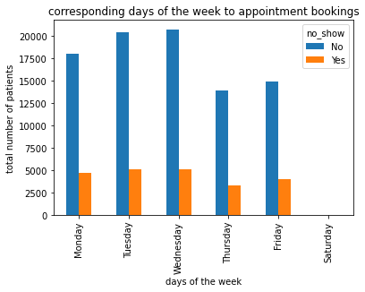

```python
# Creating an index for appointment day of the week to enable us determine if weekdays influences a patient to show up
appointment_index = ['Monday', 'Tuesday', 'Wednesday', 'Thursday', 'Friday', 'Saturday']

#ordering the index
df3['appointment_day_of_week'] = pd.Categorical(df3['appointment_day_of_week'],
                                categories=appointment_index,ordered=True)


#Grouping based on appointment_week and  and appointment, this is to enable us compare both columns
weekly_appointment = df3[['appointment_day_of_week','no_show']].groupby(['appointment_day_of_week',
                                                            'no_show']).size().reset_index(name='counts')

weekly_appointment_pivot = (
    weekly_appointment.pivot(
    values="counts",
    index="appointment_day_of_week",
    columns="no_show",
    ).sort_values('appointment_day_of_week')
    )

#using bar chart to plot the visuals
weekly_appointment_pivot.plot(kind="bar")
plt.title('corresponding days of the week to appointment bookings')
plt.xlabel("days of the week")
plt.ylabel("total number of patients")
```

#### From the bar chart above, this shows and reflects that its more convenient for patients to show up for their appointment at best in the early days of the week while weekends has the least show up.

### Question 2. How does the neighborhood affect the rate at which people show up for their appointments?

```python
#Grouping based on neighbourhood  and appointment
neighbourhood= df3[['neighbourhood','no_show']].groupby(['neighbourhood','no_show']).size().reset_index(name='counts')
neighbourhood

neighbourhood_pivot = (
  neighbourhood.pivot(
  values="counts",
  index="neighbourhood",
  columns="no_show",
  ).sort_values('neighbourhood')
)
neighbourhood_pivot.head()
```

| no_show neighbourhood | No | Yes |
| --- | --- | --- |
| AEROPORTO | 7.0 | 1.0 |
| ANDORINHAS | 1735.0 | 520.0 |
| ANTÔNIO HONÓRIO | 221.0 | 50.0 |
| ARIOVALDO FAVALESSA | 220.0 | 62.0 |
| BARRO VERMELHO | 332.0 | 91.0 |

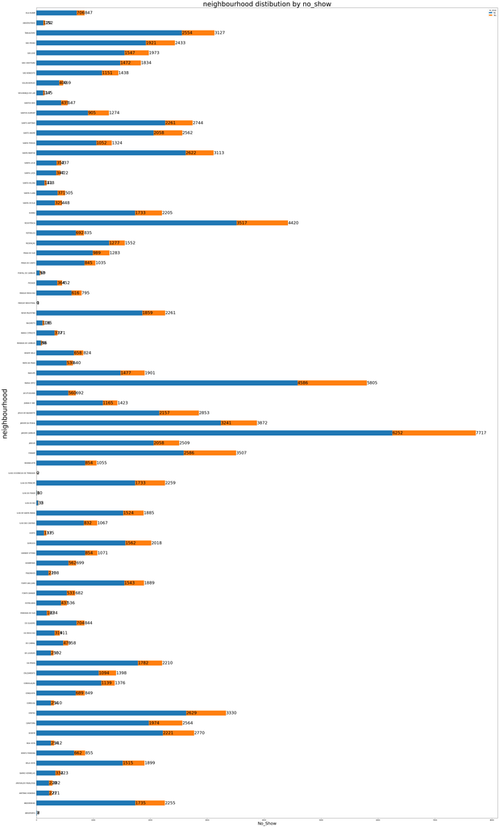

```python
#plotting details using a stacked chart

plot = neighbourhood_pivot.plot.barh(stacked=True, figsize = (50,90))
for container in plot.containers:
    plot.bar_label(container,fontsize = 25)
plt.title('neighbourhood distibution by no_show',fontsize = 40)
plt.xlabel("No_Show",fontsize = 25)
plt.ylabel("neighbourhood",fontsize = 40)
```

### Question 3. Does SMS reminders influence how patients respond to their appointments?

```python
#Grouping based on SMS_received and  and appointment
sms_counts= df3[['sms_received','no_show']].groupby(['sms_received','no_show']).size().reset_index(name='counts')
sms_counts

#comparing the columns using a pivot
sms_count_pivot = (
    sms_counts.pivot(
    values="counts",
    index="sms_received",
    columns="no_show",
    ).sort_values('sms_received')
)
sms_count_pivot
```

| no_show sms_received | No | Yes |
| --- | --- | --- |
| 0 | 62389 | 12503 |
| 1 | 25660 | 9775 |

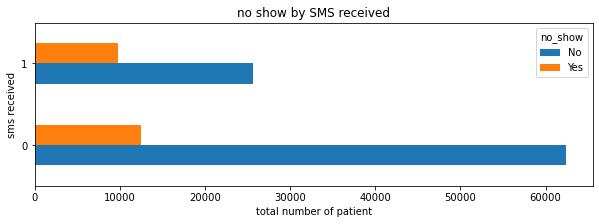

```python
#plotting the result using a barh chart
sms_count_pivot.plot(kind="barh", figsize = (10,3))
plt.title('no show by SMS received')
plt.xlabel("total number of patient")
plt.ylabel("sms received")
```

### Question 4. Are the handicapped patients able to meet or miss their appointments?

```python
#Grouping based on handicap and  and appointment
handicap_count = df3[['handicap','no_show']].groupby(['handicap','no_show']).size().reset_index(name='counts')
handicap_count

handicap_count_pivot = (
    handicap_count.pivot(
    values="counts",
    index="handicap",
    columns="no_show",
    ).sort_values('handicap')
)
handicap_count_pivot
```

| no_show handicap | No | Yes |
| --- | --- | --- |
| 0 | 86373 | 21912 |
| 1 | 1676 | 366 |

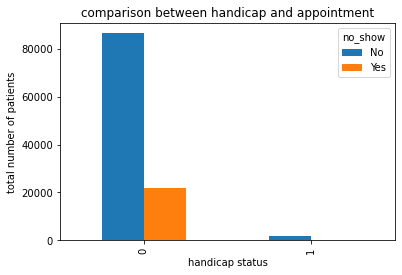

```python
#plotting the result using a bar chart
handicap_count_pivot.plot(kind="bar")
plt.title('comparison between handicap and appointment')
plt.xlabel('handicap status')
plt.ylabel('total number of patients')
```

### Question 5. How do hypertension, diabetes, and alcoholism affect the ability of patients to show up or not for their appointments?

```python
#Grouping based on hypertension,diabetes,alcoholism  and appointment
other_health_factors= df3[['hypertension','diabetes','alcoholism',
                    'no_show']].groupby(['hypertension','diabetes','alcoholism',
                    'no_show']).size().reset_index(name='counts')

health_factors= (
    other_health_factors.pivot(
    values="counts",
    index=['hypertension','diabetes','alcoholism'],
    columns="no_show"
    )
    )
health_factors
```

| hypertension | diabetes | no_show alcoholism | No | Yes |
| --- | --- | --- | --- | --- |
| 0 | 0 | 0 | 67380 | 17822 |
|  |  | 1 | 1534 | 419 |
|  | 1 | 0 | 1104 | 276 |
|  |  | 1 | 63 | 13 |
| 1 | 0 | 0 | 11787 | 2417 |
|  |  | 1 | 870 | 198 |
|  | 1 | 0 | 5101 | 1088 |
|  |  | 1 | 210 | 45 |

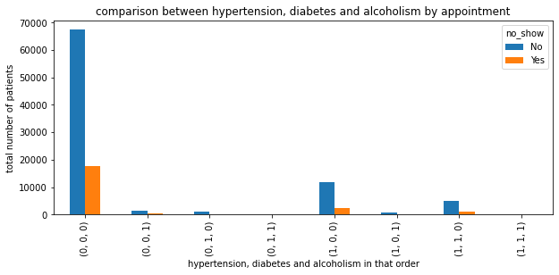

```python
#plotting the result using a barh chart
health_factors.plot(kind="bar", figsize = (10,4))
plt.title('comparison between hypertension, diabetes and alcoholism by appointment')
plt.xlabel('hypertension, diabetes and alcoholism in that order')
plt.ylabel('total number of patients')
```

### Question 6. What is the percentage of scholarship recipients? Does this affect whether they show up for their appointment or not?

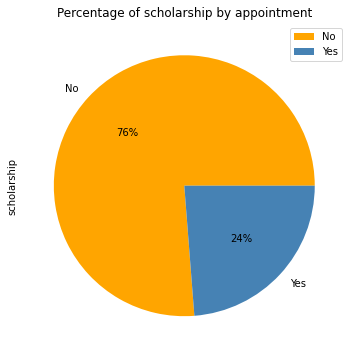

```python
#Grouping based scholarship and appointment
df3[['scholarship','no_show']].groupby(['no_show']).sum().plot(kind='pie', y='scholarship', autopct='%1.0f%%', figsize=(6,6),
colors = ['orange', 'steelblue'], title='Percentage of scholarship by appointment')
```

#### The pie chart shows that patients with the scholarship benefits show up highest for their appointment.

### Question 7. Does age group have any impact on a patient's appointment availability?

```python
# Creating an index for age_range to enable in an ascending order
age_range_index = ['<5', '5-13','13-18', '18-35', '35-65', '65+']
# Ordering the index
df3['age_range'] = pd.Categorical(df3['age_range'], categories=age_range_index, ordered=True)

#Grouping based on age_range and appointment, this is to enable us compare both columns and see if a particular age group turn up than the other
agegroup_count= df3[['age_range','no_show']].groupby(['age_range','no_show']).size().reset_index(name='counts')
agegroup_count

#comparing the columns using a pivot
agegroup_count_pivot = (
    agegroup_count.pivot(
    values="counts",
    index="age_range",
    columns="no_show",
    ).sort_values('age_range')
    )
agegroup_count_pivot
```

| no_show age_range | No | Yes |
| --- | --- | --- |
| <5 | 6644 | 1546 |
| 5-13 | 7967 | 2420 |
| 13-18 | 4968 | 1735 |
| 18-35 | 18356 | 5747 |
| 35-65 | 36020 | 8142 |
| 65+ | 11194 | 2049 |

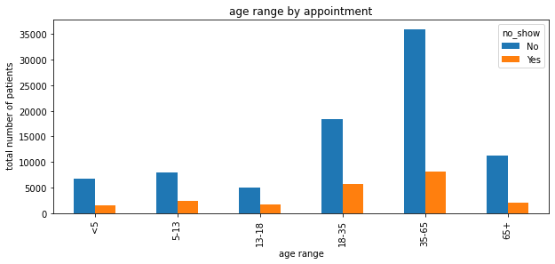

```python
#plotting the result using a bar chart
agegroup_count_pivot.plot(kind="bar", figsize=(10,4))
plt.title('age range by appointment')
plt.xlabel("age range")
plt.ylabel(" total number of patients")
```

#### From the bar chart above, it can be seen the range range between 35-65 has the highest appointment show.

### Question 8. Is there any relationship between hypertension and age among the patients?

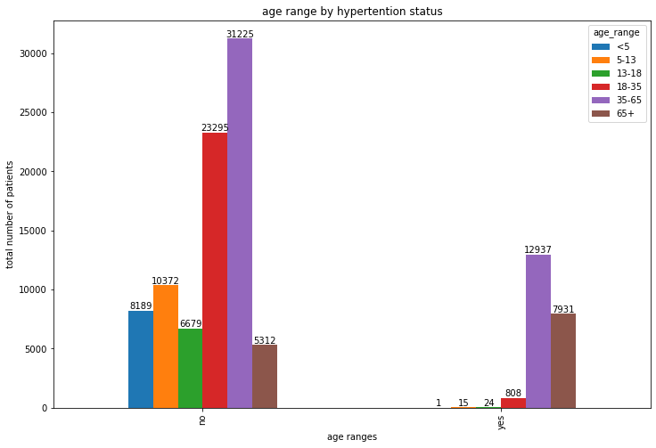

```python
#grouping age_range by hypertension
df3['has_hypertension'] = np.where(df3['hypertension']== 1, 'yes', 'no')
age_h_count= df3[['age_range','has_hypertension']].groupby(['age_range',
                'has_hypertension']).size().reset_index(name='counts')

#comparing the columns using a pivot
age_h_pivot = (
    age_h_count.pivot(
    values="counts",
    index=["has_hypertension"],
    columns="age_range",
    )
    )
#plotting the result using a bar chart
plot = age_h_pivot.plot(kind='bar', figsize=(12,8))
for container in plot.containers:
    plot.bar_label(container)
plt.title('age range by hypertention status')
plt.xlabel("age ranges")
plt.ylabel("total number of patients")
```

#### From the bar chart above, it can be seen the range range between 35-65 has the highest number of patients without hypertension , this can be as well deduced from them having the highest appointment show up as analysed earlier.

### Question 9. Is there any relationship between alcoholism and age among the patients?

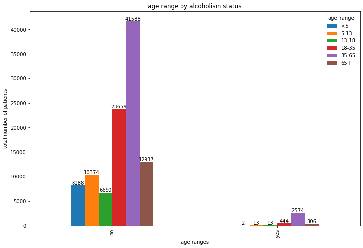

```python
#grouping age_range by alcoholism to see if its a contributor for the some patients which causes low turn up
df3['h_alcoholism'] = np.where(df3['alcoholism']== 1, 'yes', 'no')
age_h_alcoholism= df3[['age_range','h_alcoholism']].groupby(['age_range',
                'h_alcoholism']).size().reset_index(name='counts')

#comparing the columns using a pivot
age_alcoholism_pivot = (
    age_h_alcoholism.pivot(
    values="counts",
    index=["h_alcoholism"],
    columns="age_range",
    )
    )
#plotting the result using a bar chart
plot = age_alcoholism_pivot.plot(kind='bar', figsize=(12,8))
for container in plot.containers:
    plot.bar_label(container)
plt.title('age range by alcoholism status')
plt.xlabel("age ranges")
plt.ylabel("total number of patients")
```

#### From the bar chart above, it can be seen the range range between 35-65 has the highest number of patients without alcoholism, same reason as earlier stated.

### Question 10. Is there any relationship between diabetes and age among the patients?

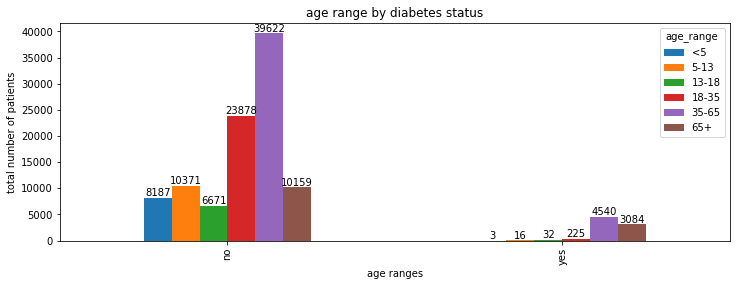

```python
#grouping age_range by diabetes to see if its a contributor for the some patients which causes low turn up
df3['h_diabetes'] = np.where(df3['diabetes']== 1, 'yes', 'no')
age_h_diabetes= df3[['age_range','h_diabetes']].groupby(['age_range',
                'h_diabetes']).size().reset_index(name='counts')

#comparing the columns using a pivot
age_diabetes_pivot = (
  age_h_diabetes.pivot(
    values="counts",
    index=["h_diabetes"],
    columns="age_range",
    )
    )
#plotting the result using a bar chart
plot = age_diabetes_pivot.plot(kind='bar', figsize=(12,4))
for container in plot.containers:
    plot.bar_label(container)
plt.title('age range by diabetes status')
plt.xlabel("age ranges")
plt.ylabel("total number of patients")
```

#### From the bar chart above, it can be seen the range range between 35-65 has the highest number of patients without diabtes, same reason as earlier stated.

### Question 11. Are patients given scholarship based on gender?

```python
#grouping gender by scholarship
gender_scholarship_count= df3[['gender','scholarship']].groupby(['gender','scholarship',]).size().reset_index(name='counts')
gender_scholarship_count
```

|  | gender | scholarship | counts |
| --- | --- | --- | --- |
| 0 | F | 0 | 62890 |
| 1 | F | 1 | 8840 |
| 2 | M | 0 | 36594 |
| 3 | M | 1 | 2003 |

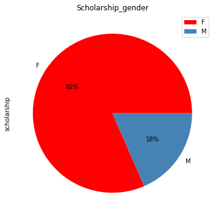

```python
#to determine scholarhip based on gender
df3[['scholarship','gender']].groupby(['gender']).sum().plot(kind='pie', y='scholarship',figsize=(6,6), autopct='%1.0f%%',
colors = ['red', 'steelblue'],title='Scholarship_gender')
```

#### The pie chart above indicates that scholarship is not on an equal basis, the female patients enjoy the scholarship opportunities higher than the male patients.

### Question 12. What is the monthly analysis of show-up and no-show appointments?

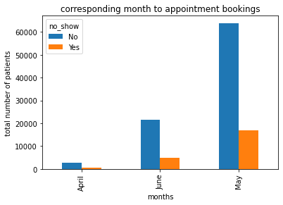

```python
#Grouping based on appointment_month and  and appointment, this is to enable us compare both columns
monthly_appointment = df3[['appointment_month_value','no_show']].groupby(['appointment_month_value',
                                                            'no_show']).size().reset_index(name='counts')
monthly_appointment_pivot = (
   monthly_appointment.pivot(
    values="counts",
    index="appointment_month_value",
    columns="no_show",
    ).sort_values('appointment_month_value')
    )

#using bar chart to plot the visuals
monthly_appointment_pivot.plot(kind="bar")
plt.title('corresponding month to appointment bookings')
plt.xlabel("months")
plt.ylabel("total number of patients")
```

#### It can be deduced from the chart above that patients show up for their appointment mostly in May while April had the least show up

# Conclusions

From the overall analysis, certain conclusions have been drawn, which include the following:

Most of the patients were generally relatively satisfied with the weekday booking of appointments, while weekends' appointments were significantly lower.

My recommendation here will be to increase awareness among patients who have indicated that they have a health condition on why it is still important for them to attend their appointment.

## Limitations

#### Lack of Previous Data for Comparisons

- The dataset was limited to the year 2016 with just 3 months, and so, we could not compare year-on-year analysis as to validate the results gotten above.

#### References

https://towardsdatascience.com/machine-learning-with-datetime-feature-engineering-predicting-healthcare-appointment-no-shows-5e4ca3a85f96 https://mrcoles.com/dateknight/